# Sample Lecture - Python

### [a hydrocode application](https://hydrocode.de)

## Overview

This is a short and quick presentation of the available elements, which can be used to build up your lecture notes.

The big advantage is, that you have to build the document only once. You can include code, models, algorithms you are currently working on. Enrich them with notes and explanations for your students.

Once, it's time for lectures you just need to mark which elements should be included into the presentation and commit the changes to github. [Notebook-Classroom](https://github.com/hydrocode-de/notebook-classroom) will take care of the rest.

## Text formatting

With markdown its **easy** to format text like *italics* or **bold and italics**.

By leaving a blank line, a new paragraph is started. Some inline $math^3_{i,j}$ can be added easily. Of course it's also possible to put formulas into their own line. $$E=mc^2$$ See the source for this formatted cell below:

```
With markdown its **easy** to format text like *italics* or _**bold and italics**_.

By leaving a blank line, a new paragraph is started. Some inline $math^3_{i,j}$ can be added easily. Of course it's also possible to put formulas into their own line.
$$E=mc^2$$
See the source for this formatted cell below:
```

### Code

It is also possible to include code that is not meant to be run (which would go into a code cell then). Most programming languages will be syntax-highlighed when included.

```
print('Like Python')
```

```
v <- "But also R"
```

```
cout << sprintf(buffer, "C++ is also %s", "known") << endl;
```

### More, More, More

of course there is way more. You will find some pretty good cheat-sheets out there: e.g. [this one](https://github.com/adam-p/markdown-here/wiki/Markdown-Cheatsheet)

## Running Code

The main advantage of using jupyter notebooks is obviously the ability to run code. We can perform calculations and explore the result interactively with the students. These cells even make it possible for students, who have never programed to change existing code with ease.

We will generate some $(x, y)$ tuples with $0 < x < 2\pi$ and $$ y = sin(x) + r $$ where $r$ is a random number $-0.1 < r < 0.1$

```python
# generate some data
x = np.linspace(0, 2*np.pi, 100)

# sine
y = np.sin(x) + (.1 * np.random.random(size=100) * np.random.choice([1., -1.], size=100))
```

The notebook will render any output to StdOut and StdErr.

```python
y
```

```
array([-0.06911659, -0.0141599 ,  0.10924699,  0.26107614,  0.16525867,
        0.31894734,  0.38656907,  0.47453967,  0.42440986,  0.46496684,
        0.67107499,  0.56843716,  0.76953673,  0.71485496,  0.72938747,
        0.78774979,  0.80865606,  0.93981613,  0.85707336,  0.98440522,
        0.88969998,  1.02564385,  0.98183071,  1.00293718,  1.09810523,
        0.97051372,  0.92882756,  0.95921823,  0.90857416,  0.88534034,
        0.94354404,  0.8253278 ,  0.96682499,  0.8909205 ,  0.78133214,
        0.87783742,  0.80169317,  0.7445939 ,  0.67353742,  0.61597618,
        0.49037193,  0.50128654,  0.446456  ,  0.37394062,  0.25440023,
        0.280729  ,  0.30149158,  0.23374342,  0.07995687, -0.05092724,
       -0.09999646, -0.12756011, -0.06496236, -0.23177603, -0.23803143,
       -0.38853375, -0.44568422, -0.38818666, -0.51419488, -0.55828112,
       -0.7030896 , -0.62486983, -0.66907388, -0.81087817, -0.84793104,
       -0.84354953, -0.86602583, -0.95649808, -0.87618335, -0.97229113,
       -1.03960893, -0.94224659, -1.04289861, -0.99072779, -1.09005562,
       -0.98871134, -0.93891932, -0.92901306, -1.04116173, -1.04762233,
       -0.94665705, -0.92559244, -0.92341154, -0.88219637, -0.84403746,
       -0.7083978 , -0.71175245, -0.69702604, -0.66996556, -0.57543028,
       -0.47175395, -0.48793603, -0.4395477 , -0.43683796, -0.3538435 ,
       -0.26528322, -0.13803925, -0.07999803, -0.15560263,  0.01291042])
```

### Plotting

The maybe coolest feature is the ability to directly inject and show plots. If you used `matplotlib`, this is straight forward. Just create a `Figure`, `Subplot` or `Axes` instance, and jupyter will take care of the rest.

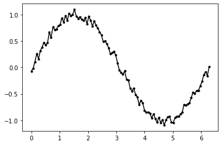

```python
plt.plot(x,y,'.-k')
```

You can use the feature-rich configuration options of `matplotlib` to perfectly adjust the plot to your needs:

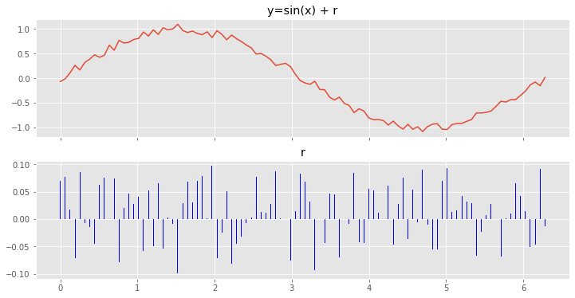

```python
# use different styling
plt.style.use('ggplot')

# create a figure with two columns
fig, ax = plt.subplots(2, 1, figsize=(12, 6), sharex=True)

# plot
ax[0].plot(x,y)
# plot 'errors'
ax[1].bar(x, np.sin(x) - y, width=0.01, color="blue")

# annotate
ax[0].set_title('y=sin(x) + r')
ax[1].set_title('r')
```

## Videos

Sometimes it's very helpful to include a video into a notebook. There are various ways how to do that. As Notebooks are capable of rendering HTML tags, you can include the video using a ordinary `iframe`. This is however not a good idea, as many Markdown processors will exclude tags like `<script>`, `<style>` or `<iframe>` from the markdown source before rendering it. But we can use the `%%HTML` cell magic of code cells to insert HTML code:

```python
%%HTML
<iframe width="560" height="315" src="https://www.youtube.com/embed/XTsaZRKx9UI?start=5" frameborder="0" allow="accelerometer; autoplay; encrypted-media; gyroscope; picture-in-picture" allowfullscreen></iframe>
```

[video not shown]

Alternatively, there is a class in the `IPython.display` module dedicated to display YouTube and Vimeo videos in a more robust way.

```python
from IPython.display import YouTubeVideo
YouTubeVideo('XTsaZRKx9UI', start=5, width=840, height=450)
```

[video not shown]

## Tables

There are many way to include tables. You can use Markdown markup to create tables. You can use HTML `<table>` tags. This is both fine, but a lot of work if you need to create large tables.

The third option is to use code cells to render tables. I.e. `pandas.DataFrame` objects will render to tables if you print them to StdOut. This way you can keep the table data in a csv and read and render it in a one-liner.

### Markdown

This table:

| head 1 | head 2 | head 3 |
| --- | --- | --- |
| cell 1 | cell 2 | cell 3 |
| cell 4 | cell 5 | cell 6 |
| cell 7 | cell 8 | cell 9 |

can be created like:

```
| head 1 | head 2 | head 3 |
|--------|--------|--------|
| cell 1 | cell 2 | cell 3 |
| cell 4 | cell 5 | cell 6 |
| cell 7 | cell 8 | cell 9 |
```

### HTML

The same as HTML table:

| head 1 | head 2 | head 3 |
| --- | --- | --- |
| cell 1 | cell 2 | cell 3 |
| cell 4 | cell 5 | cell 6 |
| cell 7 | cell 8 | cell 9 |

can be created like:

```
<table>
    <tr><th>head 1</th><th>head 2</th><th>head 3</th></tr>
    <tr><td>cell 1</td><td>cell 2</td><td>cell 3</td></tr>
    <tr><td>cell 4</td><td>cell 5</td><td>cell 6</td></tr>
    <tr><td>cell 7</td><td>cell 8</td><td>cell 9</td></tr>
</table>
```

### Python

```python
df = pd.DataFrame({'Column 1': x, 'Colum 2': y, 'Column 3': np.sin(x) - y})
df
```

|  | Column 1 | Colum 2 | Column 3 |
| --- | --- | --- | --- |
| 0 | 0.000000 | -0.069117 | 0.069117 |
| 1 | 0.063467 | -0.014160 | 0.077584 |
| 2 | 0.126933 | 0.109247 | 0.017345 |
| 3 | 0.190400 | 0.261076 | -0.071825 |
| 4 | 0.253866 | 0.165259 | 0.085889 |
| ... | ... | ... | ... |
| 95 | 6.029319 | -0.265283 | 0.014135 |
| 96 | 6.092786 | -0.138039 | -0.051212 |
| 97 | 6.156252 | -0.079998 | -0.046594 |
| 98 | 6.219719 | -0.155603 | 0.092179 |
| 99 | 6.283185 | 0.012910 | -0.012910 |

100 rows × 3 columns

An obvious downside of this kind of table is the fact that only the first few and last few lines will be printed for long tables.

There are various alternatives to plot neat tables. For juypter notebooks you can check out the `jupyter-datatables` module. Another possibility is to use `holoviews`

```python
import holoviews as hv
hv.extension('bokeh')
hv.Table(df).opts(height=350)
```

[interactive chart not shown]